# TASK 1 - DATA ANALYSIS

## 1 - Introduction and importing dataset

This dataset was downloaded through data.gov.ie. The data was collected by Google and Dublin City Council as part of a project named Air View Dublin. A car equiped with multiple sensors to detect concentration of pollutants drove through the roads of Dublin measuring street by street air quality. The measures were made at 1-second intervalls and the data collected was split apart in 2 different datasets, one of them organized by measurings on time, which depicts the car in every measuring grouped by time, and a second one data points were aggregated in aproximately 50m road segments. The latter is object of this study. This study aims to analyse the variables of the dataset and its chracteristics. The direct link for the dataset is: https://data.gov.ie/dataset/google-airview-data-dublin-city/resource/f3b5c4bf-5646-4f0b-b4f6-8e8beebcff3b?inner_span=True

```python
import pandas as pd
import math
import statistics
import statistics as stats
import numpy as np
import matplotlib.pyplot as plt
import seaborn as sns

airquality_df=pd.read_csv("https://data.smartdublin.ie/dataset/4976e11e-a015-4ef9-9179-dc7c27fb5a81/resource/f3b5c4bf-5646-4f0b-b4f6-8e8beebcff3b/download/airview_dublincity_roaddata_ugm3.csv")
```

```python
airquality_df.head()
```

|  | road_id | the_geom | osm_id | osm_code | osm_fclass | osm_name | osm_ref | osm_oneway | osm_maxspeed | osm_layer | ... | CO2_mgm3 | COpoints | COdrives | CO_mgm3 | O3points | O3drives | O3_ugm3 | PM25points | PM25drives | PM25_ugm3 |
| --- | --- | --- | --- | --- | --- | --- | --- | --- | --- | --- | --- | --- | --- | --- | --- | --- | --- | --- | --- | --- | --- |
| 0 | 3633278 | LINESTRING(-6.156470225 53.394400525, -6.15665... | 497788125 | 5141 | service | NaN | NaN | B | 30 | 0 | ... | NaN | 0 | NaN | NaN | 0 | NaN | NaN | 2 | 1.0 | 3.030 |
| 1 | 3639035 | LINESTRING(-6.3266322 53.3421535, -6.3266241 5... | 500417276 | 5141 | service | NaN | NaN | B | 0 | 0 | ... | 793.601 | 0 | NaN | NaN | 0 | NaN | NaN | 1 | 1.0 | 5.042 |
| 2 | 2099409 | LINESTRING(-6.1891464 53.3795598, -6.1895315 5... | 236680313 | 5141 | service | NaN | NaN | B | 0 | 0 | ... | 791.418 | 0 | NaN | NaN | 0 | NaN | NaN | 1 | 1.0 | 32.500 |
| 3 | 3636088 | LINESTRING(-6.2796231 53.3262885, -6.2796544 5... | 498987932 | 5141 | service | NaN | NaN | B | 0 | 0 | ... | 836.065 | 0 | NaN | NaN | 0 | NaN | NaN | 1 | 1.0 | 6.882 |
| 4 | 3962473 | LINESTRING(-6.264441 53.3131986, -6.2644378 53... | 684445633 | 5141 | service | NaN | NaN | B | 0 | 0 | ... | NaN | 0 | NaN | NaN | 1 | 1.0 | 54.447 | 1 | 1.0 | 7.111 |

5 rows × 30 columns

## 2 - Reading the data and creating a dictionary

The first step is just visualizing the name of the columns.

```python
#getting basic information of the dataset
airquality_df.info()
```

```
<class 'pandas.core.frame.DataFrame'>
RangeIndex: 24694 entries, 0 to 24693
Data columns (total 30 columns):
 #   Column        Non-Null Count  Dtype
---  ------        --------------  -----
 0   road_id       24694 non-null  int64
 1   the_geom      24694 non-null  object
 2   osm_id        24694 non-null  int64
 3   osm_code      24694 non-null  int64
 4   osm_fclass    24694 non-null  object
 5   osm_name      20209 non-null  object
 6   osm_ref       6415 non-null   object
 7   osm_oneway    24694 non-null  object
 8   osm_maxspeed  24694 non-null  int64
 9   osm_layer     24694 non-null  int64
```

[output cut: 22 more lines]

In the next step it is print the columns, with their unique values and the number of unique values in each column, to easen the visualization of the dataset and make possible to understand summarily shape of data in every column and certify its classification.

```python
#Checking unique values for every column

for column in airquality_df:
    print('Column: {} - Unique Values: {} - Number of unique: {}'.format(column, airquality_df[column].unique(), airquality_df[column].nunique()))
```

```
Column: road_id - Unique Values: [3633278 3639035 2099409 ...   21092   42617  343547] - Number of unique: 24694
Column: the_geom - Unique Values: ['LINESTRING(-6.156470225 53.394400525, -6.1566529 53.3940763)'
 'LINESTRING(-6.3266322 53.3421535, -6.3266241 53.3422119, -6.3266168 53.3422973, -6.3265935 53.3425677)'
 'LINESTRING(-6.1891464 53.3795598, -6.1895315 53.3799436)' ...
 'LINESTRING(-6.24108335 53.343096975, -6.2411545 53.3427458)'
 'LINESTRING(-6.236942 53.3380911, -6.2368972 53.3381538, -6.2368778 53.3382424, -6.23684253397864 53.3384035439329)'
 'LINESTRING(-6.24168914461433 53.342807773594, -6.2411545 53.3427458, -6.24096915300442 53.3427228196043)'] - Number of unique: 24694
Column: osm_id - Unique Values: [497788125 500417276 236680313 ...  80390834  49057073  51269108] - Number of unique: 10192
Column: osm_code - Unique Values: [5141 5122 5121 5134 5114 5111 5115 5123 5131 5135 5112 5132] - Number of unique: 12
Column: osm_fclass - Unique Values: ['service' 'residential' 'unclassified' 'secondary_link' 'secondary'
 'motorway' 'tertiary' 'living_street' 'motorway_link' 'tertiary_link'
 'trunk' 'trunk_link'] - Number of unique: 12
Column: osm_name - Unique Values: [nan 'Cooley Road' 'Quarry Road' ... 'Mespil Road' 'MacMahon Bridge'
 'Haddington Road'] - Number of unique: 3238
Column: osm_ref - Unique Values: [nan 'R812' 'L8431' 'L8145' 'R138' 'R816' 'R839' 'R825' 'R818' 'M50'
 'R137' 'L4005' 'R810' 'R131' 'L8041' 'R105' 'R112' 'R132' 'R139' 'R809'
 'L3101' 'L1084' 'R108' 'L8422' 'L8178' 'L2190' 'R102' 'R147' 'R110'
 'R117' 'L1006' 'L8107' 'R801' 'L4022' 'L3031' 'N2' 'R807' 'L8111' 'R104'
 'R803' 'L4021' 'R135' 'R107' 'R805' 'R101' 'R118' 'R820' 'R148' 'R833'
 'R819' 'R806' 'R111' 'R802' 'R804' 'R103' 'N50' 'R824' 'R811' 'L2145'
 'L3080' 'R114' 'R109' 'R808' 'L5704' 'R815' 'R817' 'L1014' 'R840' 'R834'
 'R813' 'R814'] - Number of unique: 70
Column: osm_oneway - Unique Values: ['B' 'F'] - Number of unique: 2
Column: osm_maxspeed - Unique Values: [30  0 50 20 10 16 25 60 15 80 40  8  5] - Number of unique: 13
Column: osm_layer - Unique Values: [ 0 -1  1 -3  2] - Number of unique: 5
Column: osm_bridge - Unique Values: [False  True] - Number of unique: 2
Column: osm_tunnel - Unique Values: [False  True] - Number of unique: 2
Column: NO2points - Unique Values: [   0    1    2 ...  907 1750 2774] - Number of unique: 1221
Column: NO2drives - Unique Values: [ nan   1.   2. 165.   3.   4.   5.   6.   7.   8.   9.  10.  12.  11.
 178.  13.  14.  15.  16.  17.  18.  20.  19.  21.  22.  23.  24.  25.
  26.  27.  28.  29.  30.  31.  32.  33.  34.  35.  36.  37.  38.  39.
  40.  41.  43.  42.  44.  47.  45.  46.  48.  50.  49.  51.  52.  53.
  54.  55.  56.  57.  58.  59.  60.  61.  62.  63.  67.  64.  68.  65.
  66.  69.  71.  70.  72.  74.  76.  78.  73.  79.  77.  81.  80.  82.
  85.  75.  83.  84.  86.  88.  89.  87.  90.  92.  93.  99.  97.  91.
 100. 101.  94. 105. 103. 104.  96.  95.  98. 106. 111. 108. 114. 102.
 109. 115. 116. 110. 112. 107. 122. 126. 131. 128. 130. 113. 129. 137.
 138. 136. 143. 120. 149. 158.] - Number of unique: 131
Column: NO2_ugm3 - Unique Values: [    nan -34.13    3.659 ...   6.016  17.511  30.58 ] - Number of unique: 19660
Column: NOpoints - Unique Values: [   0    1    2 ... 1230 1916 3382] - Number of unique: 1365
```

[output cut: 145 more lines]

```
Column: O3_ugm3 - Unique Values: [   nan 54.447 43.125 ... 48.29  38.765 59.397] - Number of unique: 6470
Column: PM25points - Unique Values: [   2    1    5 ... 2256 2488 3723] - Number of unique: 1419
Column: PM25drives - Unique Values: [  1.   2. 251.  nan   3.   4.   5.   6.   7.   8.   9.  10.  12.  11.
  13. 266.  15.  14.  16.  17.  18.  19.  20.  21.  22.  23.  24.  25.
  26.  27.  31.  30.  28.  29.  33.  32.  34.  35.  36.  39.  37.  38.
  40.  45.  41.  42.  43.  44.  46.  47.  48.  50.  51.  49.  52.  55.
  53.  54.  58.  56.  57.  61.  59.  60.  63.  67.  62.  64.  65.  66.
  68.  69.  70.  71.  72.  74.  75.  73.  76.  77.  79.  83.  78.  82.
  81.  80.  84.  87.  85.  86.  89.  88.  90.  93.  92.  91.  96.  99.
  94. 101.  98. 100.  95. 102.  97. 103. 106. 108. 107. 104. 109. 112.
 114. 110. 111. 113. 115. 117. 120. 116. 119. 121. 122. 123. 124. 129.
 126. 127. 125. 128. 130. 131. 133. 134. 135. 132. 137. 136. 149. 138.
 139. 140. 141. 142. 143. 144. 146. 147. 148. 151. 157. 156. 158. 161.
 165. 163. 162. 167. 168. 170. 171. 172. 176. 191. 211. 202. 215.] - Number of unique: 166
Column: PM25_ugm3 - Unique Values: [ 3.03   5.042 32.5   ...  8.699  7.878  8.28 ] - Number of unique: 8218
```

After visualizing the matrix above, we can verify that in fact the dataset presents variables according to the function info() used before, and it does not show any inconsistency at first sight.

#### From the matrix printed above, we can split the dataset in 4 different categories:

##### Identification of line segments: This information are useful if the intention is creating a map. The dataset was created to be used as a tool of analyses in ArcGis, therefore these data are important to create a physical visualisation of the data over a global map application, such as google maps.

1 - road_id: unique road segment ID - Numerical

2 - the_geom: road segment linestring, it provides coordinates to identify the linestring in a map - Categorical

3 - osm_id: OSM road ID - Numerical

4 - osm_code: OSM code - Numerical

5 - osm_name OSM road name - Categorical

##### Characteristics of line segments: This information will classify the line segments regarding its specific characteristics.

6 - osm_fclass OSM fclass / road-type - Categorical

7 - osm_ref OSM road ref - Categorical

9 - osm_maxspeed OSM description of maximum speed permitted in the via - Numerical

10 - osm_layer OSM description of level of the via (it is usefull to represent overlapping among vias and relative level) - Categorical (it was converted in numbers but its representation is categorical).

11 - osm_bridge OSM description whether via is over a bridge or not - Categorical

12 - osm_tunnel OSM description whether via is through a tunnel or not - Categorical

##### Characteristics of the measurement: This information will state characteristics of the measurement itself, and it is usefull to analyse reliability of the data row by row.

13 - NO2points number of measurements on this road segment - Numerical

14 - NO2drives number of drive passes on this road segment - Numerical

15 - NOpoints number of measurements on this road segment - Numerical

16 - NOdrives number of drive passes on this road segment - Numerical

17 - CO2points number of measurements on this road segment - Numerical

18 - CO2drives number of drive passes on this road segment - Numerical

19 - COpoints number of measurements on this road segment - Numerical

20 - COdrives number of drive passes on this road segment - Numerical

21 - O3points number of measurements on this road segment - Numerical

22 - O3drives number of drive passes on this road segment - Numerical

23 - PM25points number of measurements on this road segment - Numerical

24 - PM25drives number of drive passes on this road segment - Numerical

##### Concentration of pollutants: This is the concentration of pollutants object of this study.

25 - NO2_ugm3 NO2 concentration (median of drive pass mean) in µg/m3 - Numerical

26 - NO_ugm3 NO concentration (median of drive pass mean) in µg/m3 - Numerical

27 - CO2_mgm3 CO2 concentration (median of drive pass mean) in mg/m3 - Numerical

28 - CO_mgm3 CO concentration (median of drive pass mean) in mg/m3 - Numerical

29 - O3_ugm3 O3 concentration (median of drive pass mean) in µg/m3 - Numerical

30 - PM25_ugm3 PM2.5 concentration (median of drive pass mean) in µg/m3 - Fine particule metter that are 2.5 microns or less in diameter - Numerical

## 3 - Exploratory analysis and data cleaning

In this section it is sought to analyse if any information is useless for the scope of this project, or for some reason unrealiable, and after this process this information will be dropped or replaced properly.

```python
airquality_df.drop(['road_id', 'the_geom', 'osm_code', 'osm_id', 'osm_name','osm_ref'], axis = 1, inplace = True)
```

As discussed before osm_layer represents a categorical value converted to number, therefore it will be converted to string to easen preliminary analysis.

```python
airquality_df['osm_layer'] = airquality_df['osm_layer'].astype(str)
```

### Elimitating innacurate data according to methodology proposed

```python
airquality_df2 = airquality_df[(airquality_df.NO2points >= 10)
                            & (airquality_df.NOpoints >= 10)
                            & (airquality_df.CO2points >= 10)
                            & (airquality_df.COpoints >= 10)
                            & (airquality_df.O3points >= 10)
                            & (airquality_df.PM25points >= 10)]
```

Once innacurate data was eliminated, we need to check the variables to indentify if they contain any null value.

```python
airquality_df2.isnull().sum()
```

```
osm_fclass      0
osm_oneway      0
osm_maxspeed    0
osm_layer       0
osm_bridge      0
osm_tunnel      0
NO2points       0
NO2drives       0
NO2_ugm3        0
NOpoints        0
NOdrives        0
NO_ugm3         0
CO2points       0
CO2drives       0
CO2_mgm3        0
COpoints        0
COdrives        0
CO_mgm3         0
O3points        0
O3drives        0
O3_ugm3         0
PM25points      0
PM25drives      0
PM25_ugm3       0
dtype: int64
```

```python
airquality_df2.head()
```

|  | osm_fclass | osm_oneway | osm_maxspeed | osm_layer | osm_bridge | osm_tunnel | NO2points | NO2drives | NO2_ugm3 | NOpoints | ... | CO2_mgm3 | COpoints | COdrives | CO_mgm3 | O3points | O3drives | O3_ugm3 | PM25points | PM25drives | PM25_ugm3 |
| --- | --- | --- | --- | --- | --- | --- | --- | --- | --- | --- | --- | --- | --- | --- | --- | --- | --- | --- | --- | --- | --- |
| 46 | service | B | 20 | 0 | False | False | 5008 | 165.0 | 7.269 | 12811 | ... | 782.994 | 8770 | 256.0 | 0.341 | 1701 | 171.0 | 52.448 | 7023 | 251.0 | 5.747 |
| 76 | residential | B | 30 | 0 | False | False | 267 | 1.0 | -32.181 | 267 | ... | 790.037 | 267 | 1.0 | 0.353 | 102 | 1.0 | 83.577 | 271 | 1.0 | 4.303 |
| 137 | residential | B | 30 | 0 | False | False | 31 | 1.0 | -7.844 | 31 | ... | 807.494 | 31 | 1.0 | 0.330 | 12 | 1.0 | 76.183 | 32 | 1.0 | 2.337 |
| 144 | service | F | 30 | 0 | False | False | 43 | 1.0 | 14.474 | 41 | ... | 788.818 | 42 | 1.0 | 0.290 | 16 | 1.0 | 67.627 | 44 | 1.0 | 5.052 |
| 145 | service | B | 0 | 0 | False | False | 24 | 1.0 | -19.801 | 22 | ... | 806.284 | 24 | 1.0 | 0.342 | 11 | 1.0 | 84.658 | 25 | 1.0 | 5.071 |

5 rows × 24 columns

As explained before, columns classificed as Characteristics of measurements are useful to analyse the confiability of that measurement itself. The methodology do not suggest further steps regarding confiability of data using Characteristics of measurements, and it considers the data collected generally robust. Thus, this data will no longer be used to any further analysis and will be dropped.

```python
#After innacurate data being eliminated, columns 'Feature'points and 'Feature'drives will no longer be necessary
#therefore, they will be dropped to easen visualization of the dataset.

airquality_df3 = airquality_df2.drop(['NO2points', 'NO2drives',
                     'NOpoints', 'NOdrives',
                     'CO2points', 'CO2drives',
                     'COpoints', 'COdrives',
                     'O3points','O3drives',
                     'PM25points','PM25drives'], axis = 1)
```

```python
airquality_df3.info()
```

```
<class 'pandas.core.frame.DataFrame'>
Int64Index: 17788 entries, 46 to 24693
Data columns (total 12 columns):
 #   Column        Non-Null Count  Dtype
---  ------        --------------  -----
 0   osm_fclass    17788 non-null  object
 1   osm_oneway    17788 non-null  object
 2   osm_maxspeed  17788 non-null  int64
 3   osm_layer     17788 non-null  object
 4   osm_bridge    17788 non-null  bool
 5   osm_tunnel    17788 non-null  bool
 6   NO2_ugm3      17788 non-null  float64
 7   NO_ugm3       17788 non-null  float64
 8   CO2_mgm3      17788 non-null  float64
 9   CO_mgm3       17788 non-null  float64
 10  O3_ugm3       17788 non-null  float64
 11  PM25_ugm3     17788 non-null  float64
dtypes: bool(2), float64(6), int64(1), object(3)
memory usage: 1.5+ MB
```

## 3 - Descriptive analysis and data presentation

This section aimns to give a brief introduction of the dataset, start drawing summary conclusions, understand somewhat the shape of the dataset and its general behavior.

```python
airquality_df3.head()
```

|  | osm_fclass | osm_oneway | osm_maxspeed | osm_layer | osm_bridge | osm_tunnel | NO2_ugm3 | NO_ugm3 | CO2_mgm3 | CO_mgm3 | O3_ugm3 | PM25_ugm3 |
| --- | --- | --- | --- | --- | --- | --- | --- | --- | --- | --- | --- | --- |
| 46 | service | B | 20 | 0 | False | False | 7.269 | -7.661 | 782.994 | 0.341 | 52.448 | 5.747 |
| 76 | residential | B | 30 | 0 | False | False | -32.181 | -5.565 | 790.037 | 0.353 | 83.577 | 4.303 |
| 137 | residential | B | 30 | 0 | False | False | -7.844 | -19.309 | 807.494 | 0.330 | 76.183 | 2.337 |
| 144 | service | F | 30 | 0 | False | False | 14.474 | -9.241 | 788.818 | 0.290 | 67.627 | 5.052 |
| 145 | service | B | 0 | 0 | False | False | -19.801 | 1.681 | 806.284 | 0.342 | 84.658 | 5.071 |

After the step of cleaning and selection of the dataset according to the scope of the repport as well as the methodology of the study which has generated this dataset, it was reduced from 24694 rows and 30 columns to 17788 rows and 12 columns. Rows were reduced by 27.97%. However it is important to make clear that all data eliminated was considered with low reliability by the methodology studied, hence nevertheless less data will be used, a higher accuracy is expected to conclusions reached by the end of the study.

```python
numerical = ['osm_maxspeed','NO2_ugm3','NO_ugm3','CO2_mgm3','CO_mgm3','O3_ugm3','PM25_ugm3']
categorical = ['osm_fclass','osm_oneway','osm_layer', 'osm_bridge', 'osm_tunnel']
```

```python
airquality_df3[numerical].describe()
```

|  | osm_maxspeed | NO2_ugm3 | NO_ugm3 | CO2_mgm3 | CO_mgm3 | O3_ugm3 | PM25_ugm3 |
| --- | --- | --- | --- | --- | --- | --- | --- |
| count | 17788.000000 | 17788.000000 | 17788.000000 | 17788.000000 | 17788.000000 | 17788.000000 | 17788.000000 |
| mean | 41.321003 | 12.444767 | 7.477287 | 811.376198 | 0.374988 | 47.717049 | 6.732587 |
| std | 12.980152 | 19.819688 | 61.883027 | 35.440102 | 0.051501 | 8.990745 | 3.700826 |
| min | 0.000000 | -32.651000 | -105.857000 | 740.153000 | 0.248000 | -3.717000 | 1.474000 |
| 25% | 30.000000 | 0.394250 | -7.676500 | 793.548750 | 0.339000 | 42.569000 | 5.266750 |
| 50% | 50.000000 | 8.983000 | -2.456000 | 805.827500 | 0.365000 | 48.230000 | 6.245000 |
| 75% | 50.000000 | 20.820750 | 9.202750 | 822.874250 | 0.400000 | 53.502000 | 7.425250 |
| max | 80.000000 | 503.936000 | 1785.447000 | 2103.918000 | 1.303000 | 104.759000 | 111.691000 |

```python
((airquality_df3[numerical].std(ddof=1)/airquality_df3[numerical].mean())*100).reset_index(name ='CoefficientOfVariation')
```

|  | index | CoefficientOfVariation |
| --- | --- | --- |
| 0 | osm_maxspeed | 31.412965 |
| 1 | NO2_ugm3 | 159.261218 |
| 2 | NO_ugm3 | 827.613377 |
| 3 | CO2_mgm3 | 4.367900 |
| 4 | CO_mgm3 | 13.733901 |
| 5 | O3_ugm3 | 18.841787 |
| 6 | PM25_ugm3 | 54.968849 |

Some points can be highlighted as important information:

1 - Among the gases CO2 has the highest concentration, specially when it is verified that its unity is miligram per cubic meter, while most of the others are microgram per cubic meter. However, it is the gas with the smaller coefficient of variation. This suggests that the variables studied on this report do not affect its concentration strongly.

2 - The concetration of NO is the one with a widest range, and also the more disperse, this might indicates strong influence of other variables on the dataset over this variable.

```python
airquality_df3[categorical].describe()
```

|  | osm_fclass | osm_oneway | osm_layer | osm_bridge | osm_tunnel |
| --- | --- | --- | --- | --- | --- |
| count | 17788 | 17788 | 17788 | 17788 | 17788 |
| unique | 11 | 2 | 5 | 2 | 2 |
| top | residential | B | 0 | False | False |
| freq | 6945 | 13704 | 17483 | 17613 | 17658 |

```python
fclass = airquality_df3.osm_fclass.value_counts().rename_axis('classification').reset_index(name = 'counting')
fclass['percent']=(fclass['counting']/fclass['counting'].sum())*100
```

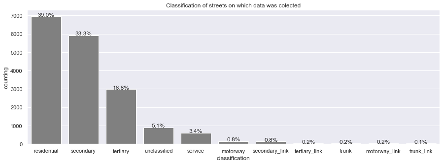

```python
fig1 = sns.barplot(data = fclass, x = 'classification', y = 'counting', color = 'grey')
sns.set(rc = {'figure.figsize':(15,5)})
patches = fig1.patches
for i in range(len(patches)):
   x = patches[i].get_x() + patches[i].get_width()/2
   y = patches[i].get_height()+.05
   fig1.annotate('{:.1f}%'.format(fclass['percent'][i]), (x, y), ha='center')
plt.title('Classification of streets on which data was colected')
plt.show()
```

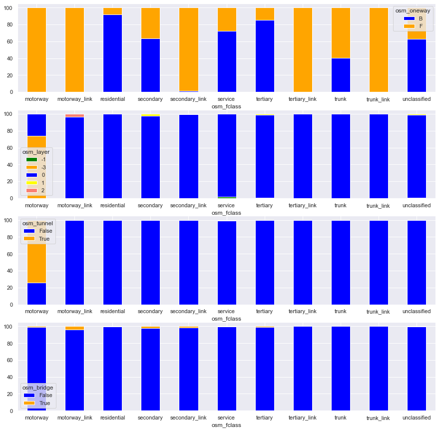

```python
sns.set(rc = {'figure.figsize':(15,15)})
fig, fig1 = plt.subplots(4,1)
oneway_by_classification = pd.crosstab(airquality_df3['osm_fclass'], airquality_df3['osm_oneway']).apply(lambda x: x/x.sum()*100, axis =1)
oneway_by_classification.plot(kind='bar',  stacked=True,
                                 rot=0, color=['blue','orange'], ax = fig1[0])
layer_by_classification = pd.crosstab(airquality_df3['osm_fclass'], airquality_df3['osm_layer']).apply(lambda x: x/x.sum()*100, axis =1)
layer_by_classification.plot(kind='bar',  stacked=True,
                                 rot=0, color=['green','orange','blue', 'yellow','salmon'], ax = fig1[1])
tunnel_by_classification = pd.crosstab(airquality_df3['osm_fclass'], airquality_df3['osm_tunnel']).apply(lambda x: x/x.sum()*100, axis =1)
tunnel_by_classification.plot(kind='bar',  stacked=True,
                                 rot=0, color=['blue','orange'], ax = fig1[2])
bridge_by_classification = pd.crosstab(airquality_df3['osm_fclass'], airquality_df3['osm_bridge']).apply(lambda x: x/x.sum()*100, axis =1)
bridge_by_classification.plot(kind='bar',  stacked=True,
                                 rot=0, color=['blue','orange'], ax = fig1[3])
```

The graph above is not useful to identify absolute values, however it is useful to identify proportions between variables on the dataset.

2 - Most of motorways are in level -3, in addition it is the only classification of street where -3 layers are found. Most of the remaining classification are in level 0.

### Analysing behavior and shape of the indicators of air quality

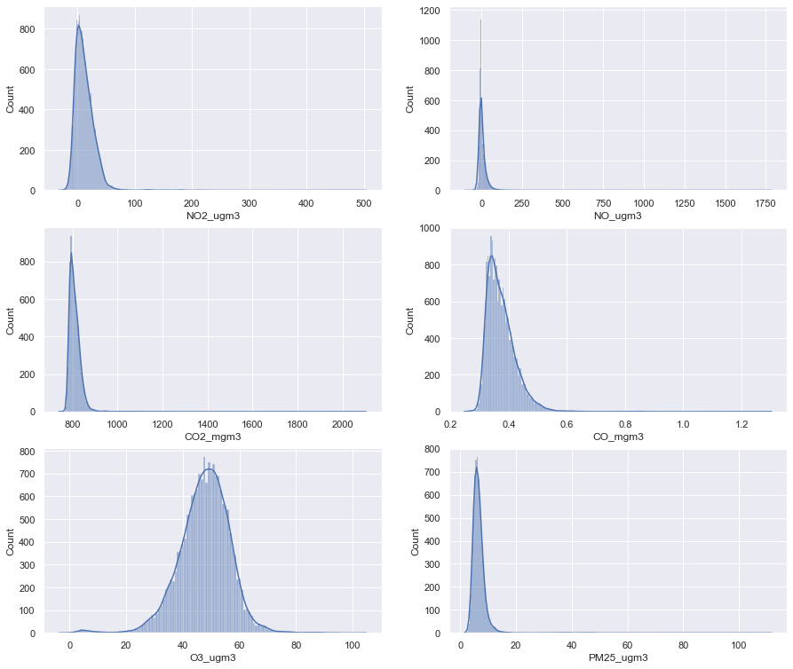

```python
sns.set(rc = {'figure.figsize':(15,13)})
fig, fig2 = plt.subplots(3,2)
sns.histplot(airquality_df3.NO2_ugm3,kde = True, ax = fig2[0,0])
sns.histplot(airquality_df3.NO_ugm3, kde = True, ax = fig2[0,1])
sns.histplot(airquality_df3.CO2_mgm3, kde = True, ax = fig2[1,0])
sns.histplot(airquality_df3.CO_mgm3, kde = True, ax = fig2[1,1])
sns.histplot(airquality_df3.O3_ugm3, kde = True, ax = fig2[2,0])
sns.histplot(airquality_df3.PM25_ugm3, kde = True, ax = fig2[2,1])

plt.show()
```

Graphs above show us the shape of concentration of pollutants analysed, it is possible verify that with exception of O3, all the rest are posively skewed, whereas O3 is nearly symmetric.

```python
#Filtering all the information in the Dataset airquality_df3 which represent the most common values found on the
#dataset according to its description
airquality_df4 = airquality_df3[(airquality_df3['osm_layer']== '0')
                              & (airquality_df3['osm_bridge'] == 0)
                              & (airquality_df3['osm_tunnel'] == 0)
                              & (airquality_df3['osm_oneway'] == 'B')
                              & (airquality_df3['osm_fclass'] == 'residential')]
```

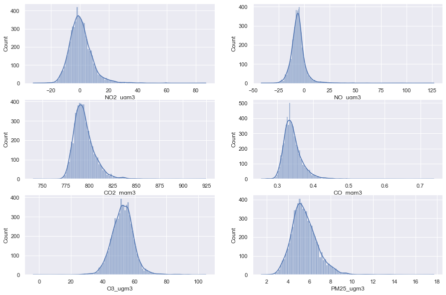

```python
sns.set(rc = {'figure.figsize':(15,10)})
fig, fig2 = plt.subplots(3,2)
sns.histplot(airquality_df4.NO2_ugm3,kde = True, ax = fig2[0,0])
sns.histplot(airquality_df4.NO_ugm3, kde = True, ax = fig2[0,1])
sns.histplot(airquality_df4.CO2_mgm3, kde = True, ax = fig2[1,0])
sns.histplot(airquality_df4.CO_mgm3, kde = True, ax = fig2[1,1])
sns.histplot(airquality_df4.O3_ugm3, kde = True, ax = fig2[2,0])
sns.histplot(airquality_df4.PM25_ugm3, kde = True, ax = fig2[2,1])

plt.show()
```

If all the features considered independent are settled to its top value, it is possible to see that the dataset, although is still posively skewed for the same variables, behaves in a much more more way, what indicates that independent variable influence on the concentration of pollutants. Although the influence might be big, it is not possible to observe in this graphs because the dataset does not provide data enough out of the top values. It would be a good aproach plotting overlapping histograms to analyse how much difference each variable make with the pollutants, however there is not data enough to this, once the data is very unbalanced. The correlation between variables can be seen in the following correlation matrix, plotted as a heatmap.

```python
airquality_df5 = airquality_df3
```

```python
#To plot a correlation matrix all the categorical variables on the dataset need to be transformed into numerical.
#In this code categorical values are being replace.
airquality_df5['osm_fclass'].replace({'service': 0, 'residential': 1, 'unclassified': 2,
                                      'secondary': 3, 'secondary_link': 4, 'tertiary': 5,
                                      'tertiary_link': 6, 'motorway_link': 7, 'motorway': 8,
                                      'trunk_link': 9, 'trunk': 10}, inplace = True)
airquality_df5['osm_oneway'].replace({'B': 0, 'F': 1}, inplace = True)
airquality_df5['osm_bridge'].replace({True: 1, False: 0}, inplace = True)
airquality_df5['osm_tunnel'].replace({True: 1, False: 0}, inplace = True)
airquality_df5['osm_layer'] = airquality_df5['osm_layer'].astype(int)
```

```python
#Recovering the original dataset for airquality_df3, that will be used above to better understanding of graphs.
airquality_df3 = airquality_df2.drop(['NO2points', 'NO2drives',
                     'NOpoints', 'NOdrives',
                     'CO2points', 'CO2drives',
                     'COpoints', 'COdrives',
                     'O3points','O3drives',
                     'PM25points','PM25drives'], axis = 1)
```

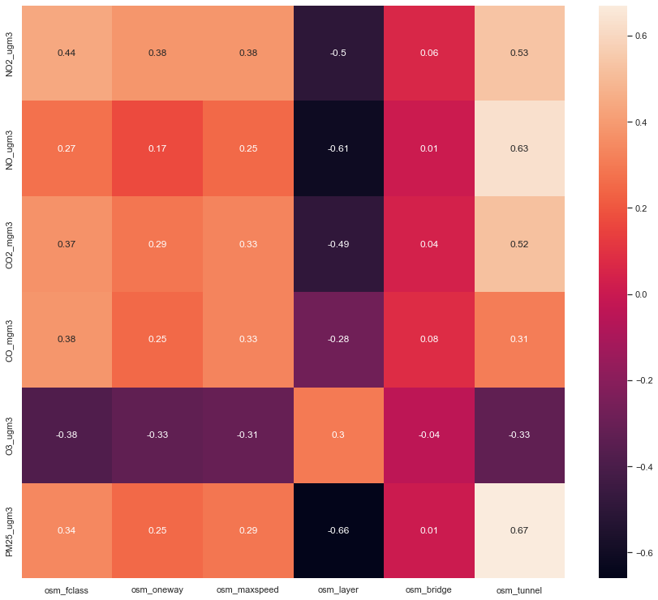

```python
correlation = airquality_df5.corr().round(2).iloc[6: , :6]
sns.heatmap(correlation, annot=True)
```

The first conclusion that can be drawn from the heatmap and correlation matrix is that O3_ugm3 is influenced in the opposite way of all the other polutants for every feature. osm_fclass, osm_oneway, osm_maxsppeed, osm_bridge and osm_tunnel, are positively correlated to all polutants except O3_ugm3, whereas osm_layer is correlated negatively to all polutants except O3_ugm3. We can also understand the osm_bridge are very weakly correlated to all variables, and therefore will not be further analysed in this report. The two variables more influent to the conentratiom are osm_tunnel, which indicates whether measure site is through a tunnel or not, and osm_layer, which indicates overlapping among vias.

### Analysing correlations with classification of streets and max speed

```python
airquality_df3.head()
```

|  | osm_fclass | osm_oneway | osm_maxspeed | osm_layer | osm_bridge | osm_tunnel | NO2_ugm3 | NO_ugm3 | CO2_mgm3 | CO_mgm3 | O3_ugm3 | PM25_ugm3 |
| --- | --- | --- | --- | --- | --- | --- | --- | --- | --- | --- | --- | --- |
| 46 | service | B | 20 | 0 | False | False | 7.269 | -7.661 | 782.994 | 0.341 | 52.448 | 5.747 |
| 76 | residential | B | 30 | 0 | False | False | -32.181 | -5.565 | 790.037 | 0.353 | 83.577 | 4.303 |
| 137 | residential | B | 30 | 0 | False | False | -7.844 | -19.309 | 807.494 | 0.330 | 76.183 | 2.337 |
| 144 | service | F | 30 | 0 | False | False | 14.474 | -9.241 | 788.818 | 0.290 | 67.627 | 5.052 |
| 145 | service | B | 0 | 0 | False | False | -19.801 | 1.681 | 806.284 | 0.342 | 84.658 | 5.071 |

To analyse correlation between the concentration of polutants, classification of streets and max speed of vias, the dataset will be grouped by osm_fclass, and all features grouped by its mean for each classification of street. Than the new dataset generate will be sorted according to max speed in descending order, and concentration will be plotted against osm_fclass organized by mean of max speed.

```python
#Grouping street classifications to find patterns within it
#Data will be sorted in order of osm_maxspeed, which is a unique caracteristic of every classification

street_class = airquality_df3.groupby('osm_fclass', axis=0).mean()
street_class.sort_values(by = 'osm_maxspeed', ascending = False, inplace= True)
street_class = street_class.reset_index()
street_class
```

|  | osm_fclass | osm_maxspeed | osm_bridge | osm_tunnel | NO2_ugm3 | NO_ugm3 | CO2_mgm3 | CO_mgm3 | O3_ugm3 | PM25_ugm3 |
| --- | --- | --- | --- | --- | --- | --- | --- | --- | --- | --- |
| 0 | motorway | 77.200000 | 0.006667 | 0.740000 | 129.843000 | 421.467527 | 1019.809427 | 0.562267 | 14.059660 | 33.876853 |
| 1 | motorway_link | 69.259259 | 0.037037 | 0.000000 | 50.032000 | 83.540741 | 861.308000 | 0.392407 | 30.735148 | 10.841926 |
| 2 | trunk | 57.297297 | 0.000000 | 0.000000 | 36.380919 | 5.688216 | 834.479730 | 0.385324 | 34.075027 | 9.322432 |
| 3 | trunk_link | 51.250000 | 0.000000 | 0.000000 | 31.872292 | -7.898375 | 834.777125 | 0.403250 | 30.605583 | 9.839125 |
| 4 | secondary | 49.956081 | 0.022973 | 0.000338 | 22.666553 | 16.646617 | 825.879387 | 0.407654 | 43.592484 | 7.416282 |
| 5 | secondary_link | 48.027211 | 0.013605 | 0.000000 | 23.291299 | 18.252054 | 820.364497 | 0.394497 | 43.374014 | 6.696503 |
| 6 | tertiary | 42.589495 | 0.009033 | 0.002007 | 11.827326 | 2.595429 | 809.552783 | 0.373676 | 47.425305 | 6.561411 |
| 7 | tertiary_link | 42.564103 | 0.000000 | 0.000000 | 12.713051 | 10.449077 | 807.646077 | 0.375154 | 47.968513 | 6.617308 |
| 8 | unclassified | 39.712389 | 0.004425 | 0.001106 | 10.705945 | -4.391814 | 807.953445 | 0.358927 | 46.804619 | 6.889968 |
| 9 | residential | 34.964723 | 0.000432 | 0.000720 | 0.948358 | -5.929260 | 795.178395 | 0.344695 | 52.448788 | 5.569327 |
| 10 | service | 12.752475 | 0.001650 | 0.008251 | 14.368246 | 5.382812 | 811.332985 | 0.379853 | 48.217913 | 6.827591 |

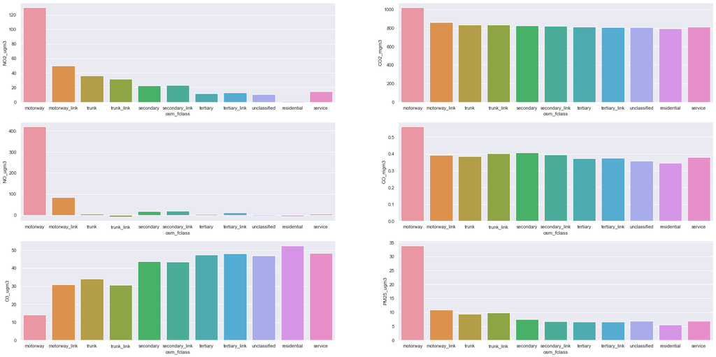

```python
sns.set(rc = {'figure.figsize':(30,15)})
fig, fig3 = plt.subplots(3,2)
sns.barplot(data = street_class, x = 'osm_fclass', y = 'NO2_ugm3', ax = fig3[0,0])
sns.barplot(data = street_class, x = 'osm_fclass', y = 'NO_ugm3', ax = fig3[1,0])
sns.barplot(data = street_class, x = 'osm_fclass', y = 'CO2_mgm3', ax = fig3[0,1])
sns.barplot(data = street_class, x = 'osm_fclass', y = 'CO_mgm3', ax = fig3[1,1])
sns.barplot(data = street_class, x = 'osm_fclass', y = 'O3_ugm3', ax = fig3[2,0])
sns.barplot(data = street_class, x = 'osm_fclass', y = 'PM25_ugm3', ax = fig3[2,1])
plt.show()
```

It seems to exist correlation between classification of street and concentration of polutants. Once the dataframe used to produce graphs were sorted by mean maximun speed of each classification, it may exist a correlation between speed of trafic and concentration of polutants.

### Analysing correlation with direction of via

```python
#Calculating the mean of different features according to osm_oneway.

airquality_df3.groupby('osm_oneway').mean()
```

| osm_oneway | osm_maxspeed | osm_bridge | osm_tunnel | NO2_ugm3 | NO_ugm3 | CO2_mgm3 | CO_mgm3 | O3_ugm3 | PM25_ugm3 |
| --- | --- | --- | --- | --- | --- | --- | --- | --- | --- |
| B | 40.07049 | 0.009267 | 0.000876 | 8.355229 | 1.762674 | 805.802159 | 0.367958 | 49.346659 | 6.227808 |
| F | 45.51714 | 0.011753 | 0.028893 | 26.167351 | 26.652864 | 830.080071 | 0.398577 | 42.248838 | 8.426390 |

### Analysing correlation with the presence of a tunnel

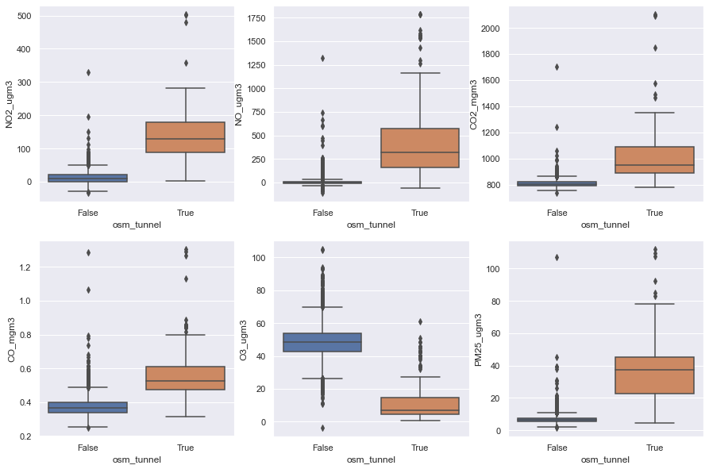

```python
sns.set(rc = {'figure.figsize':(15,10)})
sns.set()

fig, axes=plt.subplots(2,3)
sns.boxplot(x = 'osm_tunnel', y = 'NO2_ugm3', data = airquality_df3, ax=axes[0,0])
sns.boxplot(x = 'osm_tunnel', y = 'NO_ugm3', data = airquality_df3, ax=axes[0,1])
sns.boxplot(x = 'osm_tunnel', y = 'CO2_mgm3', data = airquality_df3, ax=axes[0,2])
sns.boxplot(x = 'osm_tunnel', y = 'CO_mgm3', data = airquality_df3, ax=axes[1,0])
sns.boxplot(x = 'osm_tunnel', y = 'O3_ugm3', data = airquality_df3, ax=axes[1,1])
sns.boxplot(x = 'osm_tunnel', y = 'PM25_ugm3', data = airquality_df3, ax=axes[1,2])
```

It is possible to verify that all parameters are strongly influenced by the presence of a tunnel. Concetrations of NO2, NO, CO2, CO and PM25 are significantly higher under tunnels and concetration of O3 is significantly lower. It is also possible to verify that generally under tunnels the concentration has a winder range.

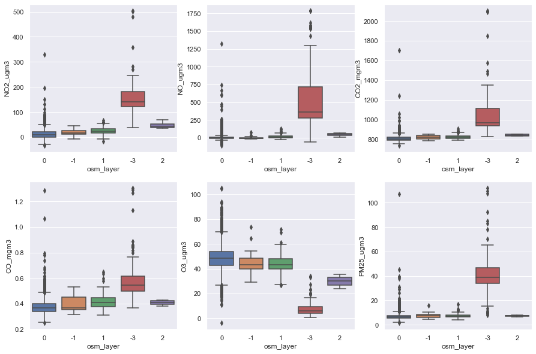

```python
sns.set(rc = {'figure.figsize':(15,10)})
sns.set()

fig, axes=plt.subplots(2,3)
sns.boxplot(x = 'osm_layer', y = 'NO2_ugm3', data = airquality_df3, ax=axes[0,0])
sns.boxplot(x = 'osm_layer', y = 'NO_ugm3', data = airquality_df3, ax=axes[0,1])
sns.boxplot(x = 'osm_layer', y = 'CO2_mgm3', data = airquality_df3, ax=axes[0,2])
sns.boxplot(x = 'osm_layer', y = 'CO_mgm3', data = airquality_df3, ax=axes[1,0])
sns.boxplot(x = 'osm_layer', y = 'O3_ugm3', data = airquality_df3, ax=axes[1,1])
sns.boxplot(x = 'osm_layer', y = 'PM25_ugm3', data = airquality_df3, ax=axes[1,2])
```

Such as happened to the variable of tunnels, presence of overlap of vias also influence the concentration of pollutants.

## 4 - Conclusion

The dataset was analysed according to its summary features, to understand shape and basic correlations among data. First, data useful only for identification of the line segments in a map, classified as Identification of Line Segments had been discarded, once this was not object of this study.

The categorical variables were also described and it was noticed that the dataset is extremely unbalanced in its observations. The large majority of the data is concentrated in the more common value for each categorical variable.

Bar plots were plotted to compare the concentration of polutants in differents classifications of streets. The classification of streets were sorted by its mean max speed in each classification. Motorways, which has the higher mean for maximum speed, had also the highest concentration of NO2, NO, CO2, CO and PM25, and lowest concentrstion for O3.

Box plots were plotted and it became clear that being under a tunnel or in vias where overlapping is found, changes the mean of concentration of pollutants.

## 5 - References

1. data.gov.ie. (n.d.). Google Project Air View Data - Dublin City (May 2021 - August 2022) - AirView_DublinCity_RoadData_CSV - data.gov.ie. [online] Available at: https://data.gov.ie/dataset/google-airview-data-dublin-city/resource/f3b5c4bf-5646-4f0b-b4f6-8e8beebcff3b?inner_span=True [Accessed 02 Apr. 2023].
2. insights.sustainability.google. (n.d.). Google Environmental Insights Explorer - Make Informed Decisions. [online] Available at: https://insights.sustainability.google/labs/airquality [Accessed 04 Apr. 2023].
3. data.smartdublin.ie. (n.d.). Google Project Air View Data - Dublin City (May 2021 - August 2022) - AirView_DublinCity_RoadData_CSV - data.smartdublin.ie. [online] Available at: https://data.smartdublin.ie/dataset/google-airview-data-dublin-city/resource/f3b5c4bf-5646-4f0b-b4f6-8e8beebcff3b [Accessed 02Apr. 2023].

# TASK 2 - PROBABILITY (DISCRETE)

## 2.1 What is the probabilty of rolling exactly two 6s in five rolls of a fair dice?

```python
import numpy as np
from numpy import random
from scipy.stats import binom
from scipy.stats import poisson
from scipy.stats import norm
```

The distribution can be noted as:

X~Bin(n=5, p=1/6)

The problem consists in finding:

P(X=2)?

The distributtion will be printed below

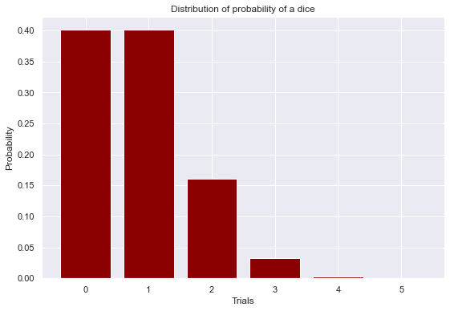

```python
x = np.linspace(0, 5, 6)
y = binom.pmf(k = x, n=5, p=1/6)
fig, ax = plt.subplots(figsize=(9,6))
ax.bar(x,y, color='darkred')
ax.set_xlabel('Trials')
ax.set_ylabel('Probability')
ax.set_title('Distribution of probability of a dice')
```

```python
a = binom.pmf(k=2,n=5,p=1/6)
print('The probability of rolling exactly two 6s in five rolls of a fair dice is:', "{:.2%}".format(a))
```

```
The probability of rolling exactly two 6s in five rolls of a fair dice is: 16.08%
```

## 2.2 What is the probability of happening a week in which no more than 2 accidents occurs?

The distribution can be noted as:

X~ Pois(λ=0.75)

The problem consists in finding:

P(X<=2)?

```python
b = poisson.cdf(k=2, mu=0.75)
print('The probability of occuring less than 2 accidents in a week is: ', "{:.2%}".format(b))
```

[output not shown]

# TASK 3 - PROBABILITY (CONTINUOUS)

```python
import scipy.stats as ss
from numpy.random import seed
from numpy.random import normal
```

The distribution can be noted as:

Z~ N(µ=90, σ=10)

mu=90 sigma=10

The distribution is represented by the graph that follows.

```python
mu=90
sigma=10
x = np.linspace(mu-4*sigma, mu+4*sigma, 100)
y = ss.norm.pdf(x, 90, 10)
```

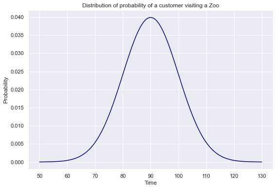

```python
fig, ax = plt.subplots(figsize=(9,6))
ax.plot(x,y, color='darkblue')
ax.set_xlabel('Time')
ax.set_ylabel('Probability')
ax.set_title('Distribution of probability of a customer visiting a Zoo')
```

## 3.1 What is the probability of a visitor selected at random spend at most 85 minutes?

If a visitor is selected at random, the probability of it spending at most 85 minutes is equivalent to:

P(Z<=85)?

The following graph brings a visual representation of the problem defined, in which calculating this probability is equivalent to calculate the area of the blue shadow under the bell curve.

The probability will be calculated in this case using the function in python norm.cdf(85, loc=90, scale=10)

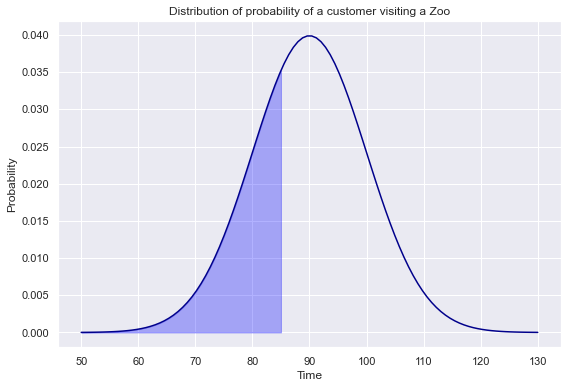

```python
fig, ax = plt.subplots(figsize=(9,6))
ax.plot(x,y, color='darkblue')
x_fill = np.linspace(mu - 4*sigma, 85, 100)
y_fill= ss.norm.pdf(x_fill, 90, 10)
ax.fill_between(x_fill, y_fill, alpha=0.3, color='blue')
ax.set_xlabel('Time')
ax.set_ylabel('Probability')
ax.set_title('Distribution of probability of a customer visiting a Zoo')
```

```python
c = norm.cdf(85, loc=90, scale=10)
print("The probability of a random visitor spend at most 85 minutes is:", "{:.2%}".format(c))
```

```
The probability of a random visitor spend at most 85 minutes is: 30.85%
```

## 3.2 What is the probability of a visitor selected at random spend at least 100 minutes?

If a visitor is selected at random, the probability of it spending at least 100 minutes is equivalent to a probability of 100% reduced the probability of spending at most 100 minutes, or in standard notation:

P(Z>=100) = 1 - P(Z<=100)

The following graph brings a visual representation of the problem defined, in which calculating this probability is equivalent to calculate the area of the blue shadow under the bell curve.

The probability will be calculated in this case using the function in python 1- norm.cdf(100, loc=90, scale=10)

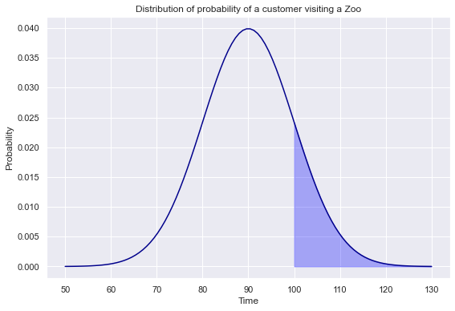

```python
fig, ax = plt.subplots(figsize=(9,6))
ax.plot(x,y, color='darkblue')
x_fill = np.linspace(100, mu+4*sigma, 100)
y_fill= ss.norm.pdf(x_fill, 90, 10)
ax.fill_between(x_fill, y_fill, alpha=0.3, color='blue')
ax.set_xlabel('Time')
ax.set_ylabel('Probability')
ax.set_title('Distribution of probability of a customer visiting a Zoo')
```

```python
d = 1-norm.cdf(100, loc=90, scale=10)
print("The probability of a random visitor spend at least 100 minutes is:", "{:.2%}".format(d))
```

```
The probability of a random visitor spend at least 100 minutes is: 15.87%
```

## 3.3 What is the probability of a visitor that is known to have spent over the average, to spend over 100 minutes?

If is known that a certain guest spent longer than the average in the zoo, it means that it has 100% of chances of having spent there over than 90 minutes. In this case, all the probability concentrates itself on the right side of the bell curve, in other words, instead of having 100% under the whole bell curve, now we have it under the right side only. Therefore, all the distribution it the right side is multiplied by 2. Hence the problem consists in calculating the area under the bell curve, after 100 minutes, what is made with 100% less the area before 100, multiplied by 2.

P(Z>=100) = 1 - 2*(P(Z<=100) - P(Z<=90))

In other notation, we can use the Baye's theorem, that stands for: P(A|B) = P(A ∩ B)/P(B) , The probability of A given B is equal to the probability of both A and B occuring divided by the probability of B.

In our example: P(Z>=100|Z>=90) = P(Z>=100 and Z>=90)/P(Z>=90) P(Z>=100 and Z>=90) = P(Z>=100) P(Z>=100|Z>=90) = P(Z>=100)/P(Z>=90) = (1-P(Z<=100))/(1-P(Z<=90))

The graph below brings a visual representation, all the red shadow area should be desconsidered, and all the concentration of probability will concentrate in the right side of the bell curve. Therefore we want to calculate the area of the blue shadow, knowing that the right side of the bell curve concentrate 100% of the probability.

The probability will be calculated in this case using in two methods:

Method 1: Function in python 1- 2*(norm.cdf(100, loc=90, scale=10)-norm.cdf(90, loc=90, scale=10)

Method 2: Function in python (1- (norm.cdf(100, loc=90, scale=10))/(1-norm.cdf(90, loc=90, scale=10))

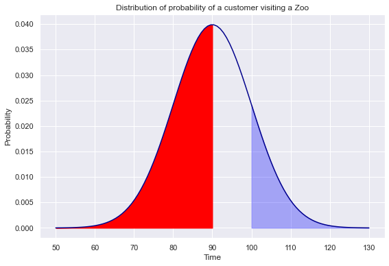

```python
fig, ax = plt.subplots(figsize=(9,6))
ax.plot(x,y, color='darkblue')
x_fill = np.linspace(100, mu+4*sigma, 100)
x_fill2 = np.linspace(mu-4*sigma,mu, 100)
y_fill= ss.norm.pdf(x_fill, 90, 10)
y_fill2 = ss.norm.pdf(x_fill2, 90, 10)
ax.fill_between(x_fill, y_fill, alpha=0.3, color='blue')
ax.fill_between(x_fill2, y_fill2, color='red')
ax.set_xlabel('Time')
ax.set_ylabel('Probability')
ax.set_title('Distribution of probability of a customer visiting a Zoo')
```

```python
#Method 1 - Using description of the problem
e = 1- 2*(norm.cdf(100, loc=90, scale=10) - norm.cdf(90, loc = 90, scale = 10))
print('The probability of certain guest spend longer than 100 minutes on the zoo, given it has spent longer than average is:', "{:.2%}".format(e))
```

```
The probability of certain guest spend longer than 100 minutes on the zoo, given it has spent longer than average is: 31.73%
```

```python
#Method 2: Using Baye's Theorem.
f = (1-norm.cdf(100, loc=90, scale=10))/(1-norm.cdf(90, loc=90, scale=10))
print('The probability of certain guest spend longer than 100 minutes on the zoo, given it has spent longer than average is:', "{:.2%}".format(f))
```

```
The probability of certain guest spend longer than 100 minutes on the zoo, given it has spent longer than average is: 31.73%
```